# Survivors and Victims, a Meta‐analytical Review of Fairness and Organizational Commitment after Downsizing

Converted from PDF `VanDierendonck-FairnessCommitmentDownsizing-2012-BJM.pdf` · 14 pages · anchors: page `#pN`, block `#pN-bK`

Page 1

## Survivors and Victims, a Meta-analytical

## Review of Fairness and Organizational

## Commitment after Downsizing

### Dirk van Dierendonck and Gabriele Jacobs Rotterdam School of Management, Erasmus University, The Netherlands

There is a lack of consistent evidence that downsizing leads to improved financial performance. Lowered commitment after painful downsizing periods is identified as an important reason why downsizing does not show the intended long-term effects. This paper provides a meta-analytical overview of the impact of fairness on organizational commitment for survivors and victims after a downsizing operation. Among 37 samples (11,256 persons), a positive relationship was found between fairness and affective organizational commitment (q 5 0.40) for both survivors and victims. Three moderators of the fairness–commitment relationship were identified: (1) for survivors, procedural justice matters more than distributive justice; (2) the impact of fairness is stronger in countries with an individualistic (versus collectivistic) culture; (3) fairness matters more when mass layoffis initiated for profit maximization (versus economic necessity).

### Introduction

Increased work productivity, technological advances, outsourcing to cheaper labour countries and global competition have led to a continuing downsizing in American and European companies. In addition, the financial crisis has accelerated mass layoffs across all sectors in Europe and the USA. During the first quarter of 2010, according to the US Bureau of Labor Statistics, employers in the USA conducted 4884 mass layoffactions. Each action involved at least 50 individuals, totalling 466,610 people. Downsizing, which is the permanent and involuntary letting go of employees by management, has become a household word in many companies. Downsizing and mass layoffs are certainly not a new phenomenon triggered by the rise of the financial crisis, but this trend, which had started already in the 1980s and 1990s, was ongoing even in a time of labour market shortages. In the 21st century, organizational restructuring through downsizing is a popular solution in order to

survive in a competitive market (Guthrie and Datta, 2008; Tyler and Wilkinson, 2007). Even companies that are well run and financially successful use layoffs as part of their regular business strategy to stay on top of their game. However, evidence for the effects on firm performance is inconclusive (Datta et al., 2010), and even within firms that reported increased firm performance, data suggest that labour productivity of the remaining work force decreased (Baumol, Blinder and Wolff, 2003).

Especially in times of crisis, organizations depend on the commitment of their employees (Baumol, Blinder and Wolff, 2003). It is safe to say that a layoffhas serious effects on all individuals involved, especially on the so-called downsizing victims and survivors. There is general agreement that downsizing results in reduced organizational commitment among survivors (for an overview see Datta et al., 2010). Therefore, lowered commitment of employees after painful downsizing periods is identified as one of the reasons why downsizing often does not

Page 2

show the intended long-term effects (Brockner, 1988; Cameron, 1994; Cascio and Wynn, 2004). Fairness is frequently positioned as a crucial factor influencing the commitment of employees towards their employers: justly treated employees are more committed (Cropanzano, Bowen and Gilliland, 2007). From a justice perspective, downsizing is an especially relevant case. There is ample evidence that the way in which a company manages its layoffimpacts the layoffsurvivors’ fairness perceptions, organizational commitment and intent to leave (for an overview see Skarlicki and Kulik, 2005). A downsizing operation breaches the implicit and explicit expectations between employees and employers, that the employee’s contribution to the organization will be reciprocated with a stable and positive work environment, and thus that good performance will result in safe employment (Charness and Levine, 2000; Gerlach et al., 2008; Kozlowski et al., 1993). This violation of expectations is perceived as most painful under those circumstances where the process and the outcomes are experienced as unfair (Cropanzano and Prehar, 2001; Zatzick and Iverson, 2006). Justice research has traditionally focused on a dyad, i.e. employee and organization. Studies on downsizing also consider this dyadic relationship, thus victim and organization, but more often focus on survivors. The latter perspective goes beyond the dyad, since survivors are so-called ‘third parties’. Although survivors are not directly affected by justice (mis)treatment by their organization, the observation of the treatment of victims is likely to impact survivors’ attitudes and behaviours. The third party perspective is important for organizations in the downsizing context. The reaction of victims to organizational treatment is observed by third parties within the organization, i.e. survivors, and outside the organization, i.e. customers or potential job candidates. Skarlicki, Ellard and Kelln (1998) found that fairness perceptions of layoffs influenced third parties’ intentions to buy the company’s products and to apply for jobs at the company at which the layoffoccurred. As third parties within the organization, survivors learn about their organization by observing the treatment of victims. These observations can affect their job attitudes and behaviours.

Consequently, the link between fairness and organizational commitment within the downsizing

context has often been studied. These empirical studies have shown a high degree of variability in the strength of the relationship between fairness and organizational commitment. The purpose of this paper is to provide a better insight into this variability by producing a state of the art metaanalytical review based on three decades of research in the field. Additionally, it aims to identify research gaps and relevant theoretical perspectives for future studies. We use a metaanalytical approach to provide a well-grounded overview of the current research and to examine potential moderators. An earlier meta-analysis on antecedents, correlates and consequences of organizational commitment confirmed the importance of fairness (Meyer et al., 2002). No attention, however, was given to the variance across studies in terms of the specific context and setting. As such, by providing an enhanced insight into processes that influence the link between fairness and organizational commitment, our paper contributes both to the downsizing literature and to the fairness and organizational commitment literature.

An important advantage of a meta-analytical approach is that hypotheses that go beyond insights provided by the individual papers or narrative reviews can be studied and tested. A meta-analysis also allows for the correction of sampling error and measurement reliability to provide us with an estimate of the average population correlations (Hunter and Schmidt, 2004). By providing a multistudy overview, this meta-analysis allows us to study three moderators that can be considered important for understanding the divergence within the relation between fairness and organizational commitment in the downsizing context:

(1) The personal situation of the people involved

(victims versus survivors). Layoffs affect employees differently: dismissed employees are influenced by a layoffin another way than their colleagues who stay with the company (Brockner et al., 1994; Skarlicki, Ellard and Kelln, 1998). (2) The cultural context of the decision (indivi-

dualism versus collectivism). In a globalized world it increasingly matters for multinationals that there are substantial cross-cultural variations in the preference for fairness rules in the downsizing context (Gerlach et al., 2008; Leung, 2005; Segalla, Jacobs and Mu¨ ller, 2001). Cultural norms can influence

Page 3

the general importance of fairness perceptions in the downsizing context. (3) The reason for the layoff(economic necessity

versus profit maximization). The arguments given for a layoffimpact the influence of the fairness perception of the downsizing operation. In the eyes of the employees, these arguments can reveal the degree of accountability of a company for the layoff(Brockner, 2002; Gopinath and Becker, 2000). When a downsizing operation takes place due to reasons beyond the influence of the company, fairness perceptions are less relevant than in the case of a layoffthat was implemented as a strategic instrument in order to maximize profit.

This paper is organized as follows. We first discuss the state of the art in fairness and commitment after downsizing. Then we present our five hypotheses in which we introduce the three moderators. After reporting our methodology and results we summarize our findings in the discussion and particularly pinpoint research gaps in the broader context of downsizing operations.

Fairness and downsizing

Three aspects of organizational fairness are generally distinguished (Greenberg and Lind, 2000). (1) Distributive fairness (Adams, 1965; Homans, 1961; Walster, Berscheid and Walster, 1973) reflects the outcomes resulting from the downsizing, e.g. in the sense that victims feel that the severance benefits provided are adequate. (2) Procedural fairness (Lind and Tyler, 1988; Thibaut and Walker, 1975) reflects the fairness of the procedures used to implement the downsizing. For procedural fairness, consistency regarding people and time is essential, as are aspects such as lack of bias, the possibility to correct wrong decisions (Clay-Warner, Hegtveldt and Roman, 2005) and the opportunity to provide information (voice) during the decisionmaking process (Lind and Tyler, 1988). (3) Interactional fairness (Bies, 2001; Bies and Moag, 1986) focuses on the interpersonal side of organizational practices in terms of the dignity and respect with which (bad) news is delivered to the individuals involved and the information provided in terms of the clarity and the adequateness of the explanation given by management.

Within this study, we will treat interactional justice as an element of procedural justice. Despite arguments from some authors that procedural and interactional justice can be considered as theoretically distinct constructs (for an overview see Bies, 2005), we follow Blader and Tyler (2003) who interpret interactional justice as a specific aspect that can hierarchically be placed within the broader framework of procedural justice. According to Blader and Tyler’s (2003) four-component model of procedural justice, behaviour within the dismissal context such as the communications by the supervisor is most probably perceived by the employees as acts and incidences of communication that symbolise the position of the organization and thus exemplify procedural justice (Rhoades and Eisenberger, 2002). This is acknowledged by the fact that many studies on justice effects within the downsizing context measure interactional fairness as an aspect of procedural justice and not as a separate dimension (e.g. Brockner et al., 1994; Mansour-Cole and Scott, 1998).

Fairness information provides a relevant source for sensemaking processes (Brockner, 2002; Weick, 1995) of employees. An important element of sensemaking is for organizational members to determine the reasons for the outcome of their social exchanges within the organization; for example, procedural fairness information is used to determine the exchange partner’s level of responsibility for the outcome. In organizational settings, social exchange takes place in ongoing relationships. Under this condition, as suggested by fairness heuristic theory (Van den Bos et al., 1999), people use procedural fairness information not only to assess the level of responsibility for the outcome, but also to determine the nature of their relationships with their exchange partners. In other words, employees use justice information to find out if their organizational authorities can be trusted. The more uncertain the situation is – and downsizing is characterized by high uncertainty – the higher the need is to engage in sensemaking processes and to use fairness information for these processes (Van den Bos and Lind, 2002; Weick, 1995).

Negative psychological consequences in the downsizing context are especially relevant to consider, since employees also use procedural fairness information to evaluate their personal responsibility for their outcomes. Downsizing changes the way in which people think about organizations and also about themselves as

Page 4

employees (Cropanzano and Prehar, 2001). After fair procedures employees are less likely to blame managers for unfavourable outcomes, which may – as a result – elicit negative self-evaluations, especially among victims of the downsizing process. Brockner (2002, p. 60) states: ‘On the one hand, greater procedural fairness may lead employees to be more supportive of the [. . .] organization. On the other hand, greater procedural fairness may lower employees’ evaluations of themselves.’

Fairness and affective organizational commitment

Commitment can broadly be defined as ‘a force [that] binds an individual to a course of action that is of relevance to a particular target’ (Meyer and Herscovitch, 2001, p. 301). In studies on organizational commitment, different forms of commitment were distinguished, namely affective, continuance and normative commitment (see for example Allen and Meyer, 1996; Meyer and Allen, 1991; Meyer et al., 2002). Although such different bases of commitment in the workplace have different causes and implications, Mathieu and Zajac (1990) concluded that affective involvement tends to be most relevant as a behavioural predictor in general. Several metaanalyses confirmed the essential role of affective organizational commitment by showing relationships with a broad range of attitudes and behaviours at work that are all crucial elements within the downsizing context, including job performance, turnover, absenteeism and organizational citizenship behaviours (e.g. Mathieu and Zajac, 1990; Meyer et al., 2002; Riketta and Van Dick, 2005). Furthermore, several studies have shown that affective commitment proved to be the strongest correlate of justice perceptions (for an overview see Meyer et al., 2002).

Affective organizational commitment can be seen as ‘an emotional attachment to, identification with, and involvement in the organization’ (Meyer et al., 2002, p. 21). In general, there is a high risk that downsizing contributes to decreased affective organizational commitment for both survivors and victims. In particular, the long-term commitment of survivors is hereby critical for the kind of employee involvement necessary for the organization to turn its performance around following a downsizing (Datta et al., 2010).

Justice aspects of a downsizing operation provide important information about the trust-

worthiness of the organization in the eyes of the employees (Skarlicki and Kulik, 2005). Employees develop global beliefs concerning the extent to which the organization values their contributions and cares about their well-being (Rhoades and Eisenberger, 2002). Fairness is a crucial source for these beliefs, and commitment is a direct response of employees who feel well supported by their organizations.

Spreitzer and Mishra (2002) reported that positive perceptions of procedural and distributive fairness during downsizing enhanced the long-term commitment of survivors, and reduced their turnover intentions. This relationship between perceptions of fairness and organizational commitment has also been established in several other studies (Cohen-Charash and Spector, 2001; Colquitt et al., 2001; Meyer et al., 2002).

Obviously, the notification of a layoffhas the most impact on the victims. These employees often remain for a significant period of time in their jobs, which can lead to counterproductive work behaviour out of frustration. Despite being allowed to stay in the organization, survivors are also influenced by the downsizing operation. Survivors and victims can respond to downsizing in significantly different ways. For example, although a layoffvictim might feel mistreated, survivors can view the layoffas fair (Skarlicki, Ellard and Kelln, 1998). Alternatively, the intense reactions of victims can trigger solidarity from survivors (Skarlicki and Kulik, 2005). Brockner and Greenberg (1990) found that layoffsurvivors who identified with the victims tended to view the layoffas unfair. From a sensemaking perspective, it should be considered that survivors care about the justice involved in the treatment their colleagues encounter since they learn about the organization and its leaders by observing how others are treated. The perception of unfairness and overtly lowered commitment of victims after a layoffcan have major effects on survivors in terms of a desire to punish the organization by lowering one’s organizational commitment for unfair dismissal procedures (Folger, Cropanzano and Goldman, 2005; Skarlicki and Kulik, 2005). As such, it can be concluded that both victims and survivors care about fairness within a downsizing operation, which leads to our first hypothesis.

H1: Fairness during a layoffis positively related to affective organizational commitment.

Page 5

The influence of the personal situation: survivors and victims

In terms of continued affective commitment, survivors are the most relevant group for the organization. Survivors stay with the organization and they will need to turn the organization around after a difficult period of downsizing. Therefore it is of crucial importance to understand the justice-related influence on the affective commitment of survivors. Studies that looked simultaneously at the impact of distributive and procedural justice found a predominant influence of procedural justice on peoples’ reactions in organizations. To capture the specific and distinct influence of these two justice dimensions, McFarlin and Sweeney (1992) introduced the two-factor model: distributive justice predicts personal outcomes such as pay satisfaction best, while procedural justice predicts system-referenced outcomes such as organizational commitment best. Distributive justice is typically not perceived as a good predictor of the general trustworthiness of an organization; procedural justice serves as fairness heuristic and a predictor for the general trustworthiness of the organization especially under the circumstances of heightened uncertainty (Van den Bos and Lind, 2002). Given that survivors experience a positive outcome – they belong to those who can stay – procedural justice will be the most important source to determine their future affective commitment to the company. Therefore we assume that survivors rely more on procedural justice than on distributive justice to determine the future trustworthiness of the organization and their organizational commitment.

H2: In a downsizing context, among survivors, procedural fairness will be more strongly related to affective organizational commitment than distributive fairness.

Opposite to survivors, for victims downsizing is a form of negative selection where they are confronted with the fact that the organization is terminating the relationship with them. According to the robust findings of the fair process effect, procedural justice matters even more when outcomes are unfavourable (for an overview see Brockner and Wiesenfeld, 2005). Dismissal is clearly an unfavourable outcome and therefore procedural justice should matter more for the affective

organizational commitment of victims than of survivors. Next to this, dismissal is a threatening, negative event that triggers feelings of uncertainty, and even though victims are going to lose their employment with the company, their relationship with this organization still matters for them in order to understand their own role and accountability of the negative event. It has been shown that layoff victims suffer from long-term effects, such as the increased concern about job security also after reemployment (Kozlowski et al., 1993).

We assume that due to feelings of high uncertainty and in the face of the highly selfrelevant negative outcome, victims have a higher need for sensemaking than survivors and therefore procedural justice matters more for victims than for survivors, which leads to the third hypothesis.

H3: Within a downsizing context, procedural fairness is more strongly correlated with affective organizational commitment among victims than among survivors.

The influence of the context: culture and the reason for downsizing

Within this meta-analysis, we also explore the influence of national culture and of the economic reason for the downsizing operation. We are looking for overall effects across the entire population. In the following two hypotheses, we will therefore neither differentiate between forms of justice nor between survivors and victims.

There are substantial cross-cultural variations in the preference for justice rules (Leung, 2005). For example, in judging the fairness of pay levels, Americans emphasize (individualistic) performance, whereas Koreans emphasize (collectivistic) group-related criteria, such as seniority, education and family size (Hundley and Kim, 1997). Similar effects were also shown for procedural justice. In resolving a dispute, the Japanese regard relationship-related goals such as maintaining a positive relationship as more important than Americans do (Ohbuchi, Kukushima and Tedeschi, 1999). Segalla, Jacobs and Mu¨ ller (2001) report that dismissal decisions across European banks are strongly driven by the nationality of the respondents. They found two distinct clusters of dismissal choices, and identified differing rationales for these choices. English human resource managers (more individualisti-

Page 6

cally oriented) use primarily performance-oriented criteria and preferably dismiss employees with the least productive worth for a company. German human resource managers (more collectivistic oriented) apply group-related criteria by also taking into account the impact of dismissal on the fired person and other colleagues.

There are still only a small number of studies exploring the cultural effect on the general importance of fairness. It was found that in countries high on power distance (Lam, Schaubroeck and Aryee, 2002) and also countries low on modernity (Farh, Earley and Lin, 1997), justice effects are weaker on organizational variables like organizational citizenship and job performance. These findings are in line with the results of a study across 43 countries that intrinsic job motivation (such as respectful treatment, recognition and personal achievement) matters less for job satisfaction in countries with low social security, high power distance and high collectivism (Huang and van de Vliert, 2003).

Of Hofstede’s (2001) original four cultural value dimensions, we consider individualism–collectivism as the crucial one in the downsizing context. Individualism–collectivism is defined as the degree to which people in a country prefer to act as individuals rather than as members of a group (Hofstede, 2001). By excluding people from a group, dismissal touches at the heart of this dimension.

Members of individualistic countries are more likely to see themselves in an exchange relationship with their organizations and to stress their individual rights, while members of collectivistic cultures tend to emphasize the views, needs and goals of their organization rather than their own interests. Employees in collectivistic countries tend to value self-actualization and individual recognition by the organization less than employees from individualistic countries (Huang and van de Vliert, 2003). Thus, members of individualistic cultures might also be more likely to use justice considerations to evaluate their exchange relationship with the organization and to determine their organizational commitment to their organization than members of collectivistic countries.

H4: Fairness has a stronger effect on affective organizational commitment in individualistic countries than in collectivistic countries.

With respect to the reasons for starting a downsizing operation, we differentiate between profit

maximization and economic necessity. Here we focus on accountability, which is a fundamental aspect of organizational justice, namely the question regarding to what extent another party is to be considered as blameworthy: ‘If no one is to blame, there is no social injustice’ (Folger and Cropanzano, 2001, p. 1). The perceived accountability for the downsizing operation will therefore influence the impact that fairness perceptions of the procedures and decision have on organizational commitment (Brockner, 2002; Skarlicki and Kulik, 2005). Employees evaluate whether other options were available and explored by management before action was taken (Greenhalgh, Lawrence and Sutton, 1988). As such, the legitimacy of the layoffdecision is also determined by the existence of layoffs in other companies in the same industry (Brockner, 1988). Fairness information on a layoffwhich is driven by purely for profit intentions, and thus under the condition of high accountability, will be experienced as more relevant and of stronger influence than within a downsizing operation which takes place due to general economic conditions that are beyond the control of the management, and thus under the condition of low accountability. When there is an economic necessity, the layoffdecision cannot be fully attributed to the organization. This (partial) lack of control of the organization will make fairness information less relevant for organizational commitment.

H5: Within downsizing operations based on profit maximization, fairness will matter more for affective organizational commitment than in downsizing operations due to economic necessity.

Our overall research model is depicted in Figure 1.

### Method

Literature search and inclusion criteria

First, a computerized search into the Psycinfo database (1970–2009) was used to identify appropriate studies for the present meta-analysis. The following search terms were used: ‘downsizing’, ‘restructuring’, ‘layoff’ and ‘layoffs’. Second, studies cited in narrative reviews on downsizing were checked. Third, a web-based search with the search engine Google Scholar was performed to determine the existence of unpublished studies. Fourth, the 15 top-tier peer-reviewed journals within the

Page 7

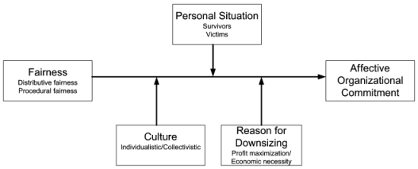

NOTE: figure/graphic rendered as an image from the PDF; its content is not machine-readable text. Caption (if any) follows as the next block.

organizational behaviour and management field were manually searched from 1980 onwards for papers missed (e.g. Journal of Applied Psychology, Academy of Management Journal, Journal of Organizational Behavior, Human Resource Management, Administrative Science Quarterly). Fifth, the authors from the studies uncovered in the previous steps were sent a personal email to ask for any unpublished data or studies in press that could be included in our meta-analysis.

The search resulted in 273 potential studies on downsizing. All abstracts were checked for relevance to be included in this meta-analysis. A study was considered for inclusion if it covered both fairness and organizational commitment. The resulting papers with relevant concepts in the abstracts were all read. To be included in the meta-analysis, the data necessary for calculating the effect size had to be provided. The end result was a database including 37 studies with 11,256 respondents. Twenty-nine studies appeared in peer-reviewed international journals and eight were unpublished dissertation studies, which meant that we could include a sufficient proportion of unpublished studies in our sample to avoid publication bias problems. Publication bias, also called the file-drawer effect, is a potential bias for meta-analysis given that statistically significant results may enhance the chance of a study being published in peerreviewed journals. The inclusion of non-published studies therefore enhances the ability to generalize the outcomes of a meta-analysis.

All studies measuring some form of affective organizational commitment were included. In total, ten different commitment scales were used. Most papers used the affective commitment scale of Meyer and Allen (1991), followed by the

organizational commitment questionnaire of Mowday, Steers and Porter (1979), Schwyhart and Smith (1972) and O’Reilly and Chatman (1986), in 12, six, five and four studies, respectively. Not all studies used the original scales; sometimes the scale was shortened or was slightly adjusted. The measurement based on the last three commitment scales all used items that captured the core of affective commitment (see Fields (2002) for an overview).

Fairness was measured with self-developed items in almost all studies. Most of the time, one or more items were formulated either based on general fairness measures or directly inspired by organizational justice literature (e.g. Leventhal, 1980). The measure developed by Brockner, Tyler and Cooper-Schneider (1992) was the only one used to measure fairness in five other studies. Distributive fairness was measured in 16 studies. Twenty-seven studies included measures of procedural fairness.

Meta-analysis procedures

This study used the Hunter–Schmidt psychometric meta-analysis method (Hunter and Schmidt, 2004) to integrate the reported correlations between fairness and organizational commitment. The correlations were corrected for the random effect of sampling error and the systematic attenuation produced by error of measurement in both the fairness and commitment scales using the internal consistency reliability. The majority of the studies included provided the reliabilities for these scales. For the few instances where the internal consistency was not provided (i.e. three of the 37 studies), the average value across the other studies was used. The average internal consistency value for fairness was 0.82 and for commitment 0.85.

Page 8

### Results

Table 1 presents the results for the overall relationship between fairness and affective organizational commitment, as well as the differentiated results for survivors compared with victims and procedural versus distributive fairness. To calculate the overall population estimate, one mean correlation was entered for each study. Thus, if both victims and survivors were surveyed in a study, or both types of fairness were included, one overall value for the correlation between fairness and commitment was calculated. In the moderator analysis, effect sizes were calculated for each specific moderator. Not all studies provided the necessary data to separate survivors from victims or procedural from

distributive fairness. This explains why the number of studies and the number of respondents in the moderator analysis do not add up exactly to the overall values in the first row.

The overall population value of the relationship between fairness and affective organizational commitment among employees undergoing a downsizing operation is strong (r 5 0.40), which is a confirmation of our first hypothesis. Sampling error accounts for only 13% of the variance which suggests that moderating effects influence the differences in effect sizes between the studies. The relationship of overall fairness and organizational commitment was the same for victims and for survivors.

For procedural fairness, the average population correlation was significantly larger than for distributive fairness (r 5 0.41 versus r 5 0.31; z score 5 6.93, po0.001). The procedure suggested by Preacher (2002) was used to calculate the significance between correlations. Next, we checked whether our argument to collapse interactional and procedural fairness was confirmed by the data. Thirteen studies (including 4533 participants) either clearly studied interactional fairness or provided separate values for procedural fairness and interactional fairness. The average corrected correlation was only slightly, and not significantly, lower than that for procedural fairness as a whole (r5 0.27, r 50.38, SDr 5 0.09; z score5 1.62, p 5 0.11), thus confirming our argument. The remainder of the analyses were performed for one score of procedural fairness.

Table 1. Meta-analysis results of the relationship between fairness and affective organizational commitment

k N r r SDr 80% CV lower

80% CV upper

95% CI lower

95% CI upper

Overall 37 11256 0.31 0.40 0.13 0.21 0.59 0.29 0.51 Individualistic 32 8008 0.36 0.42 0.15 0.23 0.62 0.30 0.54 Profit maximization 5 928 0.39 0.46 0.11 0.33 0.60 0.32 0.61 Economic necessity 13 3559 0.29 0.34 0.16 0.14 0.55 0.22 0.46 Collectivistic 5 3248 0.21 0.32 0.12 0.16 0.47 0.22 0.41 Survivors 28 8041 0.35 0.41 0.15 0.22 0.60 0.30 0.52 Victims 8 1415 0.34 0.41 0.15 0.22 0.61 0.27 0.56 Procedural fairness 27 8449 0.31 0.41 0.10 0.28 0.54 0.29 0.52 Survivors 19 5342 0.38 0.44 0.09 0.32 0.55 0.33 0.55 Victims 7 1328 0.33 0.40 0.15 0.21 0.59 0.25 0.55 Distributive fairness 16 6430 0.23 0.31 0.16 0.10 0.51 0.20 0.41 Survivors 14 4543 0.26 0.31 0.16 0.10 0.52 0.21 0.42

Note: One study reported joint data for the survivors and victims and was not included in the separate analysis for survivors and victims. Only one study focused on distributive fairness for victims. k, number of studies; N, respondents in studies; r, uncorrected correlation; r, corrected correlation; SD, standard deviation; CV, credibility interval; CI, confidence interval.

Page 9

To test our second hypothesis, we calculated the differential influence of both forms of fairness for the survivors only. Among this group, there was a larger correlation with organizational commitment for procedural fairness than for distributive fairness (r 5 0.44 versus r 5 0.31). This difference was significant and in the expected direction (z score 5 7.51, po0.001), thus confirming the hypothesis.

The third hypothesis – on the greater sensitivity of victims (versus survivors) to procedural fairness – was rejected. The difference between both groups for the average corrected correlation (r 5 0.44 versus r 5 0.40) was not significant (z score 5 1.58, p 5 0.11). We have to conclude that we can find no indication for differences between survivors and victims regarding sensitivity towards procedural fairness in its relation to organizational commitment.

### Discussion

This study addressed the relationship between fairness and affective organizational commitment for survivors and victims of a downsizing operation. This is an important issue in times when even companies on Fortune’s ‘Best company to work for’ list (such as Motorola, Xerox and IBM) are laying people off. Overall, a moderately strong relationship was found with an estimated population correlation of 0.40. Among survivors, procedural fairness was more important than distributive fairness. In countries with an individualistic culture, fairness was of more importance in relation to organizational commitment than in countries with a collectivistic culture. Moreover, if the downsizing operation was carried out for profit reasons, this sensitivity

Page 10

was stronger than when the primary reason was economic necessity.

The first contribution made by this paper is that the overall relationship between fairness and affective organizational commitment within the context of downsizing dovetails with the results reported in meta-analysis on the influence of fairness in the day-to-day functioning of organizations (Cohen-Charash and Spector, 2001; Meyer et al., 2002). Our confirmation is an important finding since the darker sides of organizational realities are often forgotten, and especially in the rough times of organizational downsizing soft factors like fairness and commitment tend to be systematically neglected. Our results indicate that explicit attention to fairness within the downsizing process is a vital driver of continued commitment in the crucial time following a downsizing operation. The strong overall corrected correlation stresses the importance of fairness for continued affective organizational commitment also after painful periods in organizational life.

The second contribution of our meta-analysis is the particular importance of procedural justice (versus distributive justice) for survivors (Folger and Konovsky, 1989; McFarlin and Sweeney, 1992; Tyler et al., 1997). Like all periods of organizational change, times of organizational downsizing are times of high uncertainty that trigger sensemaking processes. Employees who felt that they were given full and fair explanation of why and how people were dismissed are more likely to accept the layoffprocess, and to remain more positive about the organization.

There is much evidence that managerial communication has a general positive effect on affective organizational commitment after a layoff. This is not only an indirect effect through enhanced perceptions of procedural justice but also a direct effect; thus both roles of procedural justice and managerial communication play an important role for commitment after downsizing (Gopinath and Becker, 2000). This suggests that the tendency to centralize responsibility for communicating relevant organizational moves by means of the human resource department should be reconsidered. Survivors perceive procedures surrounding layoffs as fairer when their direct supervisors personally inform them (Mansour-Cole and Scott, 1998).

The third contribution of our meta-analysis is that the importance of procedural fairness was

relevant to victims. Although our hypothesis that this relationship would be stronger for victims than for survivors had to be rejected, the average corrected correlation was still moderately strong and similar to the population correlation. As such, it can be assumed that respect for victims in terms of procedural fairness may give victims a feeling of being valued (Konovsky and Folger, 1991) and also lowers their intention to take their past employer to court (Wanberg, Bunce and Gavin, 1999). This is an interesting conclusion, since most organizations fail in terms of transparency when it comes to termination decisions. Brockner (1994) suggested that one reason for this might be the fear of organizations that more transparency would provide employees with crucial information they could use in lawsuits against the organization. The opposite might be true, namely that organizations could prevent expensive lawsuits by providing their employees with the information instead of anxiously hiding it. The importance for organizations of using fair procedures with respect to victims also becomes clear in light of the fact that people who have been laid offmay be considered for re-employment later when the economy picks up again.

It should be acknowledged, however, that there is a downside to procedural fairness. High procedural justice may cause people to see themselves as more responsible. There is an inverse relationship between procedural justice and self-esteem when outcomes are unfavourable (Schroth and Shah, 2000). This finding makes the practice of high procedural fairness controversial: on the one hand, it is related to more organizational commitment, and on the other hand, it may be damaging to self-esteem when outcomes are unfavourable. This controversy is certainly an area warranting more research.

Page 11

Fifth, indications were found in our metaanalysis that a layoffwhich is driven purely for profit will be experienced differently from a downsizing which takes place due to economic necessities that are beyond the control of the management. Within a purely for profit downsizing operation the justice perspective matters more. Under this condition, the fairness–organizational commitment relationship is significantly stronger than in situations where the downsizing could be explained by general economic constraints. An interesting avenue for future research is the impact of the reasons for dismissal and the perceived accountability of the organization on the psychological consequences among employees.

Of course, this study also has some limitations. Most importantly, only 37 studies were found that fulfilled all inclusion criteria. As a result, the moderator analysis is only partly hierarchical (Hunter and Schmidt, 2004). There were simply not enough studies for a full hierarchical breakdown of all moderator variables. This means that one must be cautious about generalizing in terms of the conclusions. For example, the influence of downsizing based on profit maximization versus economic necessity could only be studied within individualistic countries. As such, we do not know how this will play out in collectivistic countries. Nevertheless, the direction of the effects in the moderator analysis is intriguing and very helpful in suggesting lines of future research. Another limitation was that only in one study was the distributive fairness for victims reported. We would like to encourage future research to consider more strongly the victims of dismissal decisions, which is clearly an underresearched area. A third limitation is the influence of sample bias (‘file-drawer problem’). It may be that studies that revealed no significant effect have never been published, nor were they part of a doctoral dissertation. The number of additional studies with a zero effect that are needed to significantly bring down the reported effect sizes can be calculated (Hunter and Schmidt, 2004). For example, it would take 36 additional studies with a zero effect to bring the overall effect size down from 0.40 to 0.20. It would take 108 studies with a zero effect to bring the overall effect size down to 0.10. We can

therefore conclude that sample bias is not likely to undermine our conclusions.

In conclusion, our findings clearly have practical implications. Although it may be tempting for management to get quickly over the inconvenient phase of downsizing, in the long run a careful and fair procedure will pay off. It is likely that having the commitment of the survivors to go for it will make all the difference between a successful and a not so successful downsizing operation.

### References

An asterisk indicates studies used in the metaanalysis.

Adams, J. S. (1965). ‘Inequity in social exchange’, Advances in

Experimental Social Psychology, 2, pp. 267–299. Allen, N. J. and J. P. Meyer (1996). ‘Affective, continuance, and

normative commitment to the organization: an examination of construct validity’, Journal of Vocational Behavior, 49, pp. 252–276. *Armstrong-Stassen, M. (1993). ‘Survivor’s reactions to a workforce reduction: a comparison of blue-collar workers and their supervisors’, Canadian Journal of Administrative Sciences, 10, pp. 334–343. *Armstrong-Stassen, M. (1993). ‘Why managers would pay greater attention to the reasons they give for a workforce reduction’, Research and Practice in Human Resource Management, 1, pp. 41–51. *Armstrong-Strassen, M., T. H. Wagar and R. J. Cattaneo (2004). ‘Work-group membership (in)stability and survivor’s reactions to organizational downsizing’, Journal of Applied Social Psychology, 34, pp. 2023–2044. Baumol, W. J., A. Blinder and E. N. Wolff(2003). Downsizing

in America: Reality, Causes and Consequences. New York: Russell Sage Foundation. Bies, R. J. (2001). ‘Interactional (in)justice: the sacred and the

profane’. In J. Greenberg and R. Cropanzano (eds), Advances in Organizational Behavior, pp. 89–118. Stanford, CA: Stanford University Press. Bies, R. J. (2005). ‘Are procedural justice and interactional

justice conceptually distinct?’. In J. A. Colquitt and J. Greenberg (eds), Handbook of Organizational Justice, pp. 85–112. Mahwah, NJ: Lawrence Erlbaum. Bies, R. J. and J. F. Moag (1986). ‘Interactional justice:

communication criteria of fairness’. In R. J. Lewicki, B. H. Sheppard and M. H. Bazerman (eds), Research on Negotiations in Organizations, pp. 43–55. Greenwich, CT: JAI Press. Blader, S. L. and T. R. Tyler (2003). ‘What constitutes fairness in

work settings? A four-component model of procedural justice’, Human Resource Management Review, 13, pp. 107–126. *Bowman, D. L. (1999). ‘Survivor reactions to downsizing in an educational organization: implications for planning organizational change’, Dissertation Abstracts Section A: Humanities and Social Sciences, 60 (3-A), 2000, 0599.

Page 12

*Brennan, A. and D. P. Skarlicki (2004). ‘Personality and perceived justice as predictors of survivors’ reactions following downsizing’, Journal of Applied Social Psychology, 34, pp. 1306–1328. Brockner, J. (1988). ‘Scope of justice in the workplace: how

survivors react to co-worker layoffs’, Journal of Social Issues, 46, pp. 95–106. Brockner, J. (1994). ‘Perceived fairness and survivors’ reactions

to layoffs, or how downsizing organizations can do well by doing good’, Social Justice Research, 7, pp. 345–371. Brockner, J. (2002). ‘Making sense of procedural fairness: how

high procedural fairness can reduce or heighten the influence of outcome favorability’, Academy of Management Review, 27, pp. 58–76. Brockner, J. and J. Greenberg (1990). ‘The impact of layoffs on

survivors: an organizational justice perspective’. In J. S. Carroll (ed.), Applied Social Psychology and Organizational Settings, pp. 45–75. Hillsdale, NJ: Erlbaum. Brockner, J. and B. Wiesenfeld (2005). ‘How, when, and why does

outcome favorability interact with procedural fairness?’. In J. Greenberg and J. A. Colquitt (eds), Handbook of Organizational Justice, pp. 525–554. Mahwah, NJ: Lawrence Erlbaum. *Brockner, J., T. R. Tyler and R. Cooper-Schneider (1992). ‘The influence of prior commitment to an institution on reactions to perceived unfairness: the higher they are, the harder they fall’, Administrative Science Quarterly, 37, pp. 241–261. *Brockner, J., B. M. Wiesenfeld and C. L. Martin (1995). ‘Decision frame, procedural justice, and survivor’s reactions to job layoffs’, Organizational Behavior and Human Decision Processes, 63, pp. 59–68. *Brockner, J., B. M. Wiesenfeld, T. Reed, S. Grover and C. Martin (1993). ‘Interactive effect of job content and context on the reactions of layoffsurvivors’, Journal of Personality and Social Psychology, 64, pp. 187–197. *Brockner, J., M. Konovsky, R. Cooper-Schneider, R. Folger, C. Martin and R. J. Bies (1994). ‘Interactive effects of procedural justice and outcome negativity on victims and survivors of job loss’, Academy of Management Journal, 37, pp. 397– 409. *Brockner, J., G. Spreitzer, A. Mishra, W. Hochwarter, L. Pepper and J. Weinberg (2004). ‘Perceived control as an antidote to the negative effects of layoffs on survivors’ organizational commitment and job performance’, Administrative Science Quarterly, 49, pp. 76–100. *Calderone, W. K. (2005). ‘Survivor reactions to organizational downsizing. The influence of justice perceptions and the psychological contract’, Dissertation Abstracts Section B: The Sciences and Engineering, 65 (12-B). Cameron, K. S. (1994). ‘Strategies for successful organizational

downsizing’, Human Resources Management Journal, 33, pp. 189–211. Cascio, W. F. and P. Wynn (2004). ‘Managing a downsizing

process’, Human Resource Management, 43, pp. 425–436. *Chang, E. (2002). ‘Distributive justice and organizational commitment revisited: moderation by layoffin the case of Korean employees’, Human Resource Management, 41, pp. 261–270. Charness, G. and D. I. Levine (2000). ‘When are layoffs

acceptable? Evidence from a quasi-experiment’, Industrial and Labor Relations Review, 53, pp. 381–400. *Clay-Warner, J., K. A. Hegtveldt and P. Roman (2005). ‘Procedural justice, distributive justice: how experiences with

downsizing condition their impact on organizational commitment’, Social Psychology Quarterly, 68, pp. 89–102. Cohen-Charash, Y. and P. E. Spector (2001). ‘The role of

justice in organizations: a meta-analysis’, Organizational Behaviour and Human Decision Processes, 86, pp. 278–321. Colquitt, J. A., D. E. Conlon, M. J. Wesson, C. O. L. H. Porter

and K. Y. Ng (2001). ‘Justice at the millennium: a metaanalytic review of 25 years of organizational justice research’, Journal of Applied Psychology, 86, pp. 425–445. Cropanzano, R. and C. A. Prehar (2001). ‘Emerging justice

concerns in an era of changing psychological contracts’. In R. Cropanzano (ed.), Justice in the Workplace: From Theory to Practice, Vol. 2, pp. 245–269. Mahwah, NJ: Lawrence Erlbaum. Cropanzano, R., D. E. Bowen and S. W. Gilliland (2007). ‘The

management of organizational justice’, Academy of Management Perspectives, 22, pp. 34–48. Datta, D. K., J. P. Guthrie, D. Basuil and A. Pandey (2010).

‘Causes and effects of employee downsizing: a review and synthesis’, Journal of Management, 36, pp. 281–348. *Davy, J. A., A. J. Kinicki and C. L. Scheck (1991). ‘Developing and testing a model of survivor responses to layoffs’, Journal of Vocational Behavior, 38, pp. 302–317. *DeWitt, R.-L., L. K. Trevino and K. A. Mollica (1998). ‘The influence of eligibility on employees’ reactions to voluntary workforce reductions’, Journal of Management, 24, pp. 593–613. *Evans, M. A. (2000). ‘An analysis and cross-validation of the role of information during downsizing’, Military Psychology, 11, pp. 345–364. Farh, J. L., P. C. Earley and S. C. Lin (1997). ‘Impetus for

action: a cultural analysis of justice and organizational citizenship behavior in Chinese society’, Administrative Science Quarterly, 42, pp. 421–444. *Ferres, N., J. Connell and A. Travaglione (2005). ‘The effect of future re-employment on organizational trust’, Strategic Change, 14, pp. 77–91. Fields, D. L. (2002). Taking the Measure of Work. A Guide to

Validated Scales for Organizational Research and Diagnosis. Thousand Oaks, CA: Sage. Folger, R. and R. Cropanzano (2001). ‘Fairness theory: justice

as accountability’. In J. Greenberg and R. Cropanzano (eds), Advances in Organizational Justice, pp. 1–56. Stanford, CA: Stanford University Press. Folger, R. and M. A. Konovsky (1989). ‘Effects of procedural

and distributive justice on reactions to pay decisions’, Academy of Management Journal, 32, pp. 115–130. Folger, R., R. Cropanzano and B. Goldman (2005). ‘What is

the relationship between justice and morality?’. In J. Greenberg and J. A. Colquitt (eds), Handbook of Organizational Justice, pp. 215–245. Mahwah, NJ: Lawrence Erlbaum. Gerlach, K., D. Levine, G. Stephan and O. Struck (2008).

‘Fairness and the employment contract: North American regions versus Germany’, Cambridge Journal of Economics, 32, pp. 421–439. *Gopinath, C. and T. E. Becker (2000). ‘Communication, procedural justice, and employee attitudes: relationships under conditions of divestiture’, Journal of Management, 26, pp. 63–83. Greenberg, J. and E. A. Lind (2000). ‘The pursuit of

organizational justice: from conceptualization to implication to application’. In C. L. Cooper and E. A. Locke (eds),

Page 13

Industrial/Organizational Psychology: What We Know about Theory and Practice, pp. 72–105. Oxford: Blackwell. Greenhalgh, L., A. Lawrence and R. Sutton (1988). ‘Determin-

ing workforce reduction strategies in declining organisations’, Academy of Management Review, 13, pp. 241–54. Guthrie, J. P. and D. K. Datta (2008). ‘Dumb and dumber: the

impact of downsizing on firm performance as moderated by industry conditions’, Organization Science, 19, pp. 108–123. *Hamilton, V. L. (2000). ‘(In)justice in waiting: Russian officers’ organizational commitment and mental distress during downsizing’, Journal of Applied Social Psychology, 30, pp. 1995–2027. Hofstede, G. (2001). Culture’s Consequences: Comparing Values, Behaviours, Institutions, and Organizations across Nations, 2nd edn. Thousand Oaks, CA: Sage. Homans, G. (1961). Social Behavior: its Elementary Forms.

New York: Harcourt, Brace, World. Huang, X. and E. van de Vliert (2003). ‘Where intrinsic job

satisfaction fails to work: national moderators of intrinsic motivation’, Journal of Organizational Behavior, 24, pp. 159–179. Hundley, G. and J. Kim (1997). ‘National culture and the

factors affecting perceptions of pay fairness in Korea and the United States’, International Journal of Organizational Analysis, 5, pp. 325–341. Hunter, J. E. and F. L. Schmidt (2004). Methods of Meta-

analysis. Correcting Error and Bias in Research Findings, 2nd edn. London: Sage. *Konovsky, M. A. and R. Folger (1991). ‘The effects of procedure, social accounts and benefit level on victim’s layoff reactions’, Journal of Applied Social Psychology, 21, pp. 630–650. Kozlowski, S., G. Chao, E. Smith and J. Hedlund (1993).

‘Organisational downsizing: strategies, interventions, and research implications’. In C. L. Cooper and I. T. Robertson (eds), International Review of Industrial and Organisational Psychology, pp. 263–332. New York: Wiley. Lam, S. S. K., J. Schaubroeck and S. Aryee (2002). ‘Relation-

ship between organizational justice and employee outcomes: a cross-national study’, Journal of Organizational Behavior, 23, pp. 1–18. *Lavelle, J. (2000). ‘Examining layoffsurvivors’ changes in targets of commitment: differentiating the effects of interactional and procedural injustice’, Dissertation Abstracts Section A: Humanities and Social Sciences, 60 (12-A), 2000, 4507. *Lee, J. and J. M. Corbett (2006). ‘The impact of downsizing on employees’ affective commitment’, Journal of Managerial Psychology, 21, pp. 176–199. Leung, K. (2005). ‘How generalizable are justice effects across

cultures?’. In J. A. Colquitt and J. Greenberg (eds), Handbook of Organizational Justice, pp. 555–588. Mahwah, NJ: Lawrence Erlbaum. *Leung, A. S. M. and L. M. K. Chang (1999). ‘The impact of organizational downsizing: psychological dynamics on surviving managers in Hong Kong’, Asia Pacific Business Review, 8, pp. 76–94. Leventhal, G. S. (1980). ‘What should be done with equity theory?

New approaches to the study of fairness in social relations’. In K. J. Gergen, M. S. Greenberg and R. H. Willis (eds), Social Exchange Theory, pp. 27–55. New York: Plenum. Lind, E. A. and T. R. Tyler (1988). The Social Psychology of

Procedural Justice. New York: Plenum.

*Mansour-Cole, D. M. and S. G. Scott (1998). ‘Hearing it through the grapevine: the influence of source, leaderrelations, and legitimacy on survivor’s fairness perceptions’, Personnel Psychology, 51, pp. 25–54. *Martin, C. L., C. K. Parsons and N. Bennett (1995). ‘The influence of employee involvement program membership during downsizing: attitudes toward the employer and the union’, Journal of Management, 21, pp. 879–890. Mathieu, J. E. and D. M. Zajac (1990). ‘A review and meta-

analysis of the antecedents, correlates, and consequences of organizational commitment’, Psychological Bulletin, 108, pp. 171–194. McFarlin, D. B. and P. D. Sweeney (1992). ‘Distributive and

procedural justice as predictors of satisfaction with personal and organizational factors’, Academy of Management Journal, 35, pp. 626–637. Meyer, J. P. and N. J. Allen (1991). ‘A three-component

conceptualization of organizational commitment’, Human Resource Management Review, 1, pp. 61–89. Meyer, J. P. and L. Herscovitch (2001). ‘Commitment in the

workplace: toward a general model’, Human Resource Management Review, 11, pp. 299–326. Meyer, J. P., D. J. Stanley, L. Herscovitch and L. Topolnytsky

(2002). ‘Affective, continuance, and normative commitment to the organization: a meta-analysis of antecedents, correlates and consequences’, Journal of Vocational Behavior, 61, pp. 20–52. *Morrall, A. Jr (1997). ‘The effect of downsizing survivors perceived inequity: impact and perception’, Dissertation Abstracts Section A: Humanities and Social Sciences, 58 (4-A), 1364. Mowday, R., R. Steers and L. Porter (1979). ‘The measurement

of organizational commitment’, Journal of Vocational Behavior, 14, pp. 224–227. *Naumann, S. E., N. Bennett and C. L. Martin (1998). ‘Laid off, but still loyal: the influence of perceived justice and organizational support’, International Journal of Conflict Management, 9, pp. 356–368. Ohbuchi, K., O. Kukushima and J. T. Tedeschi (1999).

‘Cultural values in conflict management: goal orientation, goal attainment, and tactical decision’, Journal of Cross- Cultural Psychology, 30, pp. 51–71. O’Reilly, C. and J. Chatman (1986). ‘Organizational commit-

ment and psychological attachment: the effects of compliance, identification and internalization on prosocial behavior’, Journal of Applied Psychology, 71, pp. 492–499. *Patel, R. (2000) ‘Testing an organizational commitment model in the context of a downsizing Russian military’. Unpublished doctoral dissertation, George Washington University, Washington, DC. *Paterson, J. M. and J. Cary (2002). ‘Organizational justice, change anxiety, and acceptance of downsizing: preliminary test of an AET-based model’, Motivation and Emotion, 26, pp. 83–103. Preacher, K. J. (2002). ‘Calculation for the test of the difference

between two independent correlation coefficients’ (computer software). Available from http://www.quantpsy.org. Rhoades, L. and R. Eisenberger (2002). ‘Perceived organiza-

tional support: a review of the literature’, Journal of Applied Psychology, 87, pp. 698–714. Riketta, M. and R. Van Dick (2005). ‘Foci of attachment in

organizations: a meta-analytic comparison of the strengths

Page 14

and correlates of workgroup versus organizational identification and commitment’, Journal of Vocational Behavior, 67, pp. 490–510. Schroth, H. and P. Shah (2000). ‘Procedures, do we really want to

know them?’, Journal of Applied Psychology, 85, pp. 462–471. Schwyhart, W. R. and P. C. Smith (1972). ‘Factors in the job

involvement of middle managers’, Journal of Applied Psychology, 56, pp. 227–233. Segalla, M., G. Jacobs and C. Mu¨ ller (2001). ‘Cultural

influences on employee termination decisions: firing the good, average or the old?’, European Management Journal, 19, pp. 58–72. Skarlicki, D. P. and C. T. Kulik (2005). ‘Third-party reactions

to employee (mis)treatment: a justice perspective’, Research in Organizational Behavior, 26, pp. 185–231. Skarlicki, D. P., J. H. Ellard and B. R. C. Kelln (1998). ‘Third-

party perceptions of a layoff: procedural, derogation, and retributive aspects of justice’, Journal of Applied Psychology, 82, pp. 434–443. *Spreitzer, G. M. and A. K. Mishra (2002). ‘To stay or to go: voluntary survivor turnover following an organizational downsizing’, Journal of Organizational Behavior, 23, pp. 707–729. Thibaut, J. and L. Walker (1975). Procedural Justice: A

Psychological Analysis. Hillsdale, NJ: Erlbaum. *Turnley, W. H. and D. C. Feldman (1999). ‘The impact of psychological contract violations on exit, voice, loyalty, and neglect’, Human Relations, 52, pp. 895–922. Tyler, M. and A. Wilkinson (2007). ‘The tyranny of corporate

slenderness: corporate anorexia as a metaphor of our age’, Work, Employment and Society, 2, pp. 537–549. Tyler, T. R., R. J. Beckmann, H. J. Smith and Y. J. Huo (1997).

Social Justice in a Diverse Society. Boulder, CO: Westview Press.

*Unckless, A. L. (1999). ‘Survivors’ reactions to organizational downsizing: an application of threat rigidity theory’, Dissertation Abstracts Section B: The Sciences and Engineering, 60 (1–B), 0401. Van den Bos, K. and E. A. Lind (2002). ‘Uncertainty

management by means of fairness judgments’. In M. P. Zanna (ed.), Advances in Experimental Social Psychology, Vol. 34, pp. 1–60. San Diego, CA: Academic Press. Van den Bos, K., J. Bruins, H. A. M. Wilke and E. Dronkert

(1999). ‘Sometimes unfair procedures have nice aspects: on the psychology of the fair process effect’, Journal of Personality and Social Psychology, 77, pp. 324–336. *Verdi, W. M. (1996). ‘Layoffsurvivors, layoffjustice, and layoff explanation content: their effects on organizational commitment and trust in management’, Dissertation Abstracts Section B: The Sciences and Engineering, 57 (1-B), 0746. Walster, E., E. Berscheid and G. W. Walster (1973). ‘New

directions in equity research’, Journal of Personality and Social Psychology, 25, pp. 151–176. *Wanberg, C. R., L. W. Bunce and M. B. Gavin (1999). ‘Perceived fairness of layoffs among individuals who have been laid off: a longitudinal study’, Personnel Psychology, 52, pp. 59–84. Weick, K. (1995). Sensemaking in Organizations. Newbury

Park, CA: Sage. *Wiesenfeld, B. M., J. Brockner and V. Thibault (2000). ‘Procedural fairness, manager’s self-esteem, and managerial behaviors following a layoff’, Organizational Behavior and Human Decision Processes, 83, pp. 1–32. Zatzick, C. D. and R. D. Iverson (2006). ‘High-involvement

management and workforce reduction: competitive advantage or disadvantage?’, Academy of Management Journal, 49, pp. 999–1015.

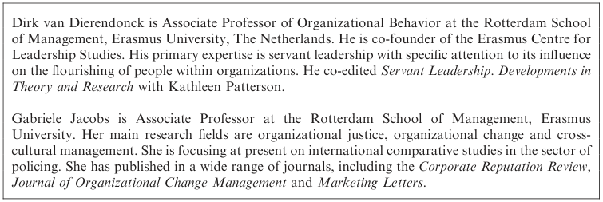

NOTE: figure/graphic rendered as an image from the PDF; its content is not machine-readable text. Caption (if any) follows as the next block.

**text found inside the figure**

Dirk van Dierendonck is Associate Professor of Organizational Behavior at the Rotterdam School of Management, Erasmus University, The Netherlands. He is co-founder of the Erasmus Centre for Leadership Studies. His primary expertise is servant leadership with specific attention to its influence on the flourishing of people within organizations. He co-edited Servant Leadership. Developments in Theory and Research with Kathleen Patterson.

Gabriele Jacobs is Associate Professor at the Rotterdam School of Management, Erasmus University. Her main research fields are organizational justice, organizational change and crosscultural management. She is focusing at present on international comparative studies in the sector of policing. She has published in a wide range of journals, including the Corporate Reputation Review, Journal of Organizational Change Management and Marketing Letters.